# VID - Projet

# 1 Introduction

Ce projet est réalisé dans le cadre du cours “Visualisation des données” à l’HEIG. Nous avons été mandatés pour traiter le sujet des bandes dans le domaine de l’impression rotogravure. En effet, ces bandes se produisent lorsque des stries ou des rainures sont présentent sur le cylindre. Dès lors qu’une bande est détectée, l’impression est arrêtée et le cylindre doit être réparé / remplacé.

Notre objectif est d’identifier certaines anomalies et les relations entre l’apparition de ces bandes et certaines variables recueillies à l’impression. Notre but serait aussi de sélectionner les variables les plus importantes pour réduire la complexité de la recherche.

Pour cela, nous allons utiliser la méthodologie CRISP-DM incluant les étapes de la compréhension du problème, la compréhension des données, la préparation des données ainsi que la sélection des attributs.

Afin de réaliser ceci, nous utiliserons un jeu de données comportant 540 enregistrement recueillis dans les années 1990 nommé bands3.csv

# 2 Compréhension des données

## 2.1 Chargement des libraries

Pour commencer, nous chargeons les librairies nécessaires pour la réalisation du projet.

```r
library(here)
library(tidyr)
library(ggplot2)
library(dplyr)
library(corrplot)
library(RColorBrewer)
library(shiny)
library(rpart.plot)
library(DT)
library(DataExplorer)
library(randomForest)
library(DMwR2)
library(scales)
library(gridExtra)
library(rpart)
```

## 2.2 Charger le jeu de données

Cela fait, nous pouvons charger le jeu de données. On spécifie que les valeurs nulles sont représentées par “?” et le séparateur par défaut “;”.

```r
cylinder <- read.csv("data/bands3.csv", sep=";", na.strings="?")
```

## 2.3 Description des données

Avant de commencer, attardons nous sur les différentes variables présentes dans le jeu de données.

- date : Il s’agit de la date à laquelle chaque observation a été recueillie.
- cylinder number: C’est un attribut nominal qui désigne un numéro d’identification unique pour chaque cylindre utilisé dans le processus.
- customer: Il s’agit du numéro de client pour lequel l’impression est effectuée.
- job number: Il s’agit d’un numéro d’identification unique pour chaque travail.
- grain screened: Indique si le grain a été tamisé ou non.
- ink color: Désigne la couleur de l’encre utilisée. Les valeurs possibles sont “key” et “type”.
- proof on ctd ink: Indique si une preuve sur l’encre ctd a été réalisée ou non.
- blade mfg: Fabricant de la lame utilisée.
- cylinder division: Il s’agit de la division de l’entreprise qui gère le cylindre.
- paper type: Type de papier utilisé pour l’impression.
- ink type: Type d’encre utilisé.
- direct steam: Indique si la vapeur directe est utilisée ou non.
- solvent type: Type de solvant utilisé.
- type on cylinder: Indique si un type est présent sur le cylindre ou non.
- press type: Type de presse utilisée.
- press: Modèle de presse utilisée.
- unit number: Numéro de l’unité de production.
- cylinder size: Taille du cylindre utilisé.
- paper mill location: Emplacement de l’usine de papier fournissant le papier.
- plating tank: Désigne le réservoir de plaquage utilisé.
- proof cut: Mesure numérique liée au processus de production.
- viscosity: Mesure de la viscosité du fluide utilisé.
- caliper: Mesure de l’épaisseur du papier ou du matériel imprimé.
- ink temperature: Température de l’encre.
- humidity: Niveau d’humidité lors de la production.
- roughness: Mesure de la rugosité du produit final.
- blade pressure: Pression de la lame utilisée.
- varnish pct: Pourcentage de vernis utilisé.
- press speed: Vitesse de la presse utilisée.
- ink pct: Pourcentage d’encre utilisée.
- solvent pct: Pourcentage de solvant utilisé.
- ESA Voltage: Tension de l’ESA.
- ESA Amperage: Ampérage de l’ESA.
- wax: Quantité de cire utilisée.
- hardener: Quantité de durcisseur utilisée.
- roller durometer: Mesure de la dureté du rouleau utilisé.
- current density: Densité du courant dans le processus.
- anode space ratio: Ratio de l’espace d’anode.
- chrome content: Teneur en chrome.
- band type: Type de bande produit, soit une bande soit pas de bande. Il s’agit de la variable cible pour la prédiction.

## 2.4 Visualisation des données

Ensuite, nous pouvons jeter un premier coup d’oeil au jeu de données :

```r
datatable(cylinder, options = list(scrollX = TRUE))
```

|  | date | cylinder_no | customer | job_number | grain_screened | ink_color | proof_ink | blade_mfg | cylinder_division | paper_type | ink_type | direct_steam | solvent_type | cylinder_type | press_type | press | unit_number | cylinder_size | location | plating_tank | proof_cut | viscosity | caliper | ink_temperature | humidity | roughness | blade_pressure | varnish_pct | press_speed | … |
| --- | --- | --- | --- | --- | --- | --- | --- | --- | --- | --- | --- | --- | --- | --- | --- | --- | --- | --- | --- | --- | --- | --- | --- | --- | --- | --- | --- | --- | --- | --- |
| 1 | 19910108 | X126 | TVGUIDE | 25503 | YES | KEY | YES | BENTON | GALLATIN | UNCOATED | UNCOATED | NO | LINE | YES | Motter94 | 821 | 2 | TABLOID | NorthUS | 1911 | 55 | 46 | 0.2 | 17 | 78 | 0.75 | 20 | 13.1 | 1700 | … |
| 2 | 19910109 | X266 | TVGUIDE | 25503 | YES | KEY | YES | BENTON | GALLATIN | UNCOATED | UNCOATED | NO | LINE | YES | Motter94 | 821 | 2 | TABLOID | NorthUS |  | 55 | 46 | 0.3 | 15 | 80 | 0.75 | 20 | 6.6 | 1900 | … |
| 3 | 19910104 | B7 | MODMAT | 47201 | YES | KEY | YES | BENTON | GALLATIN | UNCOATED | COATED | NO | LINE | YES | WoodHoe70 | 815 | 9 | CATALOG | NorthUS |  | 62 | 40 | 0.433 | 16 | 80 |  | 30 | 6.5 | 1850 | … |
| 4 | 19910104 | T133 | MASSEY | 39039 | YES | KEY | YES | BENTON | GALLATIN | UNCOATED | UNCOATED | NO | LINE | YES | WoodHoe70 | 816 | 9 | CATALOG | NorthUS | 1910 | 52 | 40 | 0.3 | 16 | 75 | 0.3125 | 30 | 5.6 | 1467 | … |
| 5 | 19910111 | J34 | KMART | 37351 | NO | KEY | YES | BENTON | GALLATIN | UNCOATED | COATED | NO | LINE | YES | WoodHoe70 | 816 | 2 | TABLOID |  | 1910 | 50 | 46 | 0.3 | 17 | 80 | 0.75 | 30 | 0 | 2100 | … |
| 6 | 19910104 | T218 | MASSEY | 38039 | YES | KEY | YES | BENTON | GALLATIN | UNCOATED | UNCOATED | NO | LINE | YES | WoodHoe70 | 816 | 2 | CATALOG | NorthUS | 1910 | 50 | 40 | 0.267 | 16.8 | 76 | 0.4375 | 28 | 8.6 | 1467 | … |
| 7 | 19910111 | X249 | ROSES | 35751 | NO | KEY | YES | BENTON | GALLATIN | COATED | COATED | NO | LINE | YES | Motter94 | 827 | 2 | TABLOID | CANADIAN | 1911 | 50 | 46 | 0.3 | 16.5 | 75 | 0.75 | 30 | 0 | 2600 | … |
| 8 | 19910111 | X788 | ROSES | 35751 | NO | KEY | YES | BENTON | GALLATIN | COATED | COATED | NO | LINE | YES | Motter94 | 827 | 9 | TABLOID | CANAdiAN | 1911 | 50 | 46 | 0.2 | 16.5 | 75 | 0.75 | 28 | 0 | 2600 | … |
| 9 | 19910112 | M372 | MODMAT | 47201 | YES | KEY | YES | BENTON | GALLATIN | UNCOATED | UNCOATED | NO | XYLOL | YES | Albert70 | 802 | 7 | CATALOG | NorthUS | 1910 | 50 | 45 | 0.367 | 12 | 70 | 0.75 | 60 | 0 | 1650 | … |
| 10 | 19910114 | I320 | CHILDCRAFT | 37000 | YES | KEY | YES | BENTON | GALLATIN | UNCOATED | UNCOATED | NO | LINE | YES | WoodHoe70 | 815 | 2 | CATALOG | NorthUS | 1911 | 65 | 43 | 0.333 | 16 | 75 | 1 | 32 | 22.7 | 1750 | … |

[output cut: 530 more lines]

On peut aussi visualiser les types de chaque colonnes ainsi que certaines de ces valeurs.

```r
str(cylinder)
```

```
'data.frame':   540 obs. of  40 variables:
 $ date             : int  19910108 19910109 19910104 19910104 19910111 19910104 19910111 19910111 19910112 19910114 ...
 $ cylinder_no      : chr  "X126" "X266" "B7" "T133" ...
 $ customer         : chr  "TVGUIDE" "TVGUIDE" "MODMAT" "MASSEY" ...
 $ job_number       : int  25503 25503 47201 39039 37351 38039 35751 35751 47201 37000 ...
 $ grain_screened   : chr  "YES" "YES" "YES" "YES" ...
 $ ink_color        : chr  "KEY" "KEY" "KEY" "KEY" ...
 $ proof_ink        : chr  "YES" "YES" "YES" "YES" ...
 $ blade_mfg        : chr  "BENTON" "BENTON" "BENTON" "BENTON" ...
 $ cylinder_division: chr  "GALLATIN" "GALLATIN" "GALLATIN" "GALLATIN" ...
 $ paper_type       : chr  "UNCOATED" "UNCOATED" "UNCOATED" "UNCOATED" ...
 $ ink_type         : chr  "UNCOATED" "UNCOATED" "COATED" "UNCOATED" ...
 $ direct_steam     : chr  "NO" "NO" "NO" "NO" ...
 $ solvent_type     : chr  "LINE" "LINE" "LINE" "LINE" ...
 $ cylinder_type    : chr  "YES" "YES" "YES" "YES" ...
```

[output cut: 26 more lines]

Nous pouvons aussi jeter un coup d’oeil aux données en utilisant la librairie “DataExplorer”.

```r
introduce(cylinder)
```

```
  rows columns discrete_columns continuous_columns all_missing_columns
1  540      40               16                 24                   0
  total_missing_values complete_rows total_observations memory_usage
1                  999           277              21600       190184
```

On remarque sur ce graphique qu’il y a un peu plus de colonnes continues par rapport aux colonnes discrètes et on remarque aussi qu’il y a que 50% de lignes complètes.

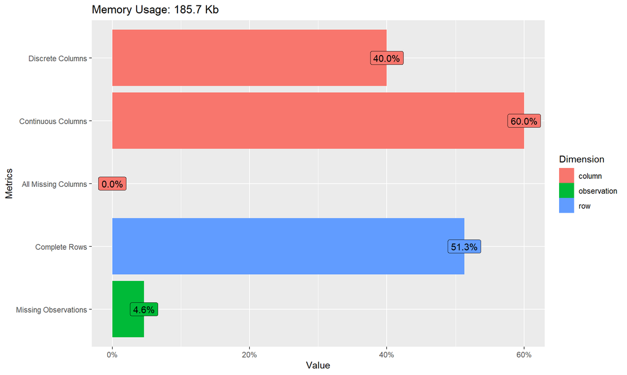

```r
plot_intro(cylinder)
```

On peut aussi visualiser le nombre de valeurs manquantes comme ceci.

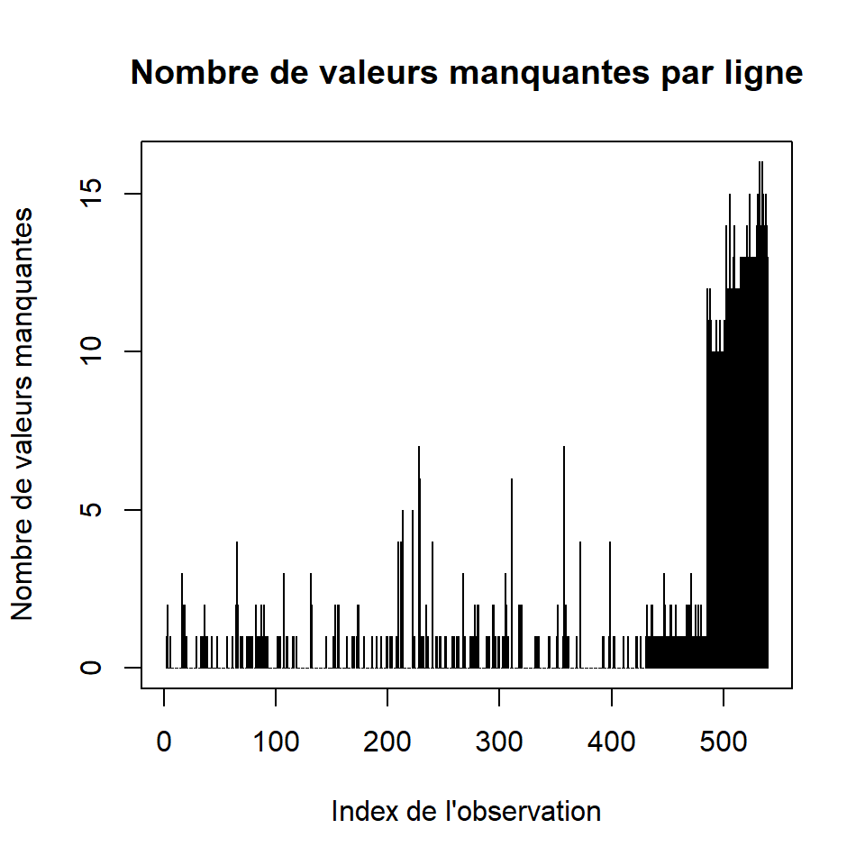

```r
num_missing <- rowSums(is.na(cylinder))
plot(num_missing, type='h', main='Nombre de valeurs manquantes par ligne', xlab='Index de l\'observation', ylab='Nombre de valeurs manquantes')
```

On remarque que les dernières observations ajoutées sont moins pertinentes car elles comportent beaucoup de valeurs manquantes et sont de moins bonne qualité. On peut supposer que ces données avaient été ajoutées par une autre personne qui n’avait pas toutes les compétences nécessaires.

# 3 Préparation des données

Une fois les données étudiées, nous pouvons commencer à préparer les données. Cette étape inclut la transformation des attributs, la gestion des valeurs manquantes ainsi que les valeurs aberrantes et la gestion des caractères (majuscule / minuscule). Nous allons aussi supprimer les attributs non-pertinents.

## 3.1 Transformation des attributs textuels

Premièrement, nous transformons les attributs textuels pour qu’ils soient tous stockés en minuscule. Cela nous évitera d’avoir différentes catégories pour ce qui devait être une seule catégorie. Ex : coated et COATED doivent représenter la même catégorie.

```r
cylinder1 <- cylinder %>% mutate(across(where(is.character), tolower))
```

## 3.2 Transformation des attributs numériques et facteurs.

Ensuite, nous transformons les données en valeurs quantitatives ou qualitatives afin d’uniformiser le jeu de données et simplifier la recherche.

```r
quali<-c(2:20,40)
quanti <- setdiff(1:40, quali)

cylinder1.quali<-cylinder1[,quali] %>% mutate(across(where(is.integer), as.factor))
cylinder1.quali<-cylinder1.quali %>%  mutate(across(where(is.character), as.factor))

cylinder1.quanti<-cylinder1[,quanti]
cylinder2<-cbind(cylinder1.quanti,cylinder1.quali)

summary(cylinder2)
```

```
      date            proof_cut       viscosity        caliper
 Min.   :19900330   Min.   :25.00   Min.   :35.00   Min.   :0.1330
 1st Qu.:19900909   1st Qu.:40.00   1st Qu.:43.00   1st Qu.:0.2000
 Median :19910117   Median :45.00   Median :50.00   Median :0.2670
 Mean   :19907801   Mean   :45.04   Mean   :50.94   Mean   :0.2757
 3rd Qu.:19910604   3rd Qu.:50.00   3rd Qu.:56.00   3rd Qu.:0.3000
 Max.   :19941010   Max.   :72.50   Max.   :72.00   Max.   :0.5330
                    NA's   :55      NA's   :5       NA's   :27
 ink_temperature    humidity        roughness       blade_pressure
 Min.   :11.20   Min.   : 57.00   Min.   :0.05625   Min.   :16.0
 1st Qu.:14.60   1st Qu.: 73.00   1st Qu.:0.62500   1st Qu.:25.0
 Median :15.20   Median : 78.00   Median :0.75000   Median :30.0
 Mean   :15.36   Mean   : 78.55   Mean   :0.72451   Mean   :30.9
 3rd Qu.:16.00   3rd Qu.: 82.00   3rd Qu.:0.81250   3rd Qu.:33.0
 Max.   :24.50   Max.   :105.00   Max.   :1.25000   Max.   :70.0
 NA's   :2       NA's   :1        NA's   :30        NA's   :63
  varnish_pct      press_speed      ink_pct       solvent_pct
 Min.   : 0.000   Min.   :   0   Min.   :41.00   Min.   :22.00
 1st Qu.: 0.000   1st Qu.:1600   1st Qu.:52.10   1st Qu.:36.80
 Median : 3.400   Median :1800   Median :56.75   Median :38.50
 Mean   : 5.781   Mean   :1823   Mean   :55.64   Mean   :38.57
 3rd Qu.:10.425   3rd Qu.:2042   3rd Qu.:58.80   3rd Qu.:41.20
 Max.   :35.800   Max.   :2600   Max.   :76.90   Max.   :53.40
 NA's   :56       NA's   :10     NA's   :56      NA's   :56
  ESA_voltage      ESA_amperage          wax           hardener
 Min.   : 0.000   Min.   :0.00000   Min.   :0.000   Min.   :0.0000
 1st Qu.: 0.000   1st Qu.:0.00000   1st Qu.:2.400   1st Qu.:0.8000
 Median : 0.000   Median :0.00000   Median :2.500   Median :1.0000
 Mean   : 1.319   Mean   :0.03814   Mean   :2.399   Mean   :0.9871
 3rd Qu.: 2.000   3rd Qu.:0.00000   3rd Qu.:2.600   3rd Qu.:1.0000
 Max.   :16.000   Max.   :6.00000   Max.   :3.100   Max.   :3.0000
 NA's   :57       NA's   :55        NA's   :6       NA's   :7
 roller_durometer current_density anode_space_ratio chrome_content
 Min.   :28.00    Min.   :30.00   Min.   : 83.33    Min.   : 90.00
 1st Qu.:30.00    1st Qu.:40.00   1st Qu.:100.00    1st Qu.:100.00
 Median :34.00    Median :40.00   Median :103.13    Median :100.00
 Mean   :34.78    Mean   :39.06   Mean   :103.04    Mean   : 99.59
 3rd Qu.:40.00    3rd Qu.:40.00   3rd Qu.:106.45    3rd Qu.:100.00
 Max.   :60.00    Max.   :45.00   Max.   :117.86    Max.   :100.00
 NA's   :55       NA's   :7       NA's   :7         NA's   :3
```

[output cut: 16 more lines]

```
 solvent_type cylinder_type     press_type      press     unit_number
 line  :468   no  :136      albert70 : 78   816    :103   1 : 34
 naptha:  2   yes :386      motter70 : 48   815    : 89   2 :247
 xylol : 15   NA's: 18      motter94 :238   821    : 77   5 : 13
 NA's  : 55                 woodhoe70:176   824    : 63   6 :  4
                                            802    : 62   7 : 85
                                            827    : 59   9 :148
                                            (Other): 87   10:  9
 cylinder_size         location   plating_tank  band_type
 catalog:178   canadian    :159   1910:332     band  :228
 spiegel: 60   mideuropean : 15   1911:190     noband:312
 tabloid:299   northus     :189   NA's: 18
 NA's   :  3   scandanavian: 13
               southus     :  8
               NA's        :156
```

## 3.3 Suppression du bruit

```r
cylinder3 <- filter(cylinder2, date < 19920000 | is.na(date))
percentage_na <- apply(cylinder3, 1, function(x) sum(is.na(x))/length(x))
cylinder3 <- cylinder3[percentage_na <= 0.20,]
```

On peut visualiser à nouveau le graphique des données manquantes pour visualiser que la suppression effectuée s’est bien déroulée et a supprimé le bruit à la fin du jeu de données.

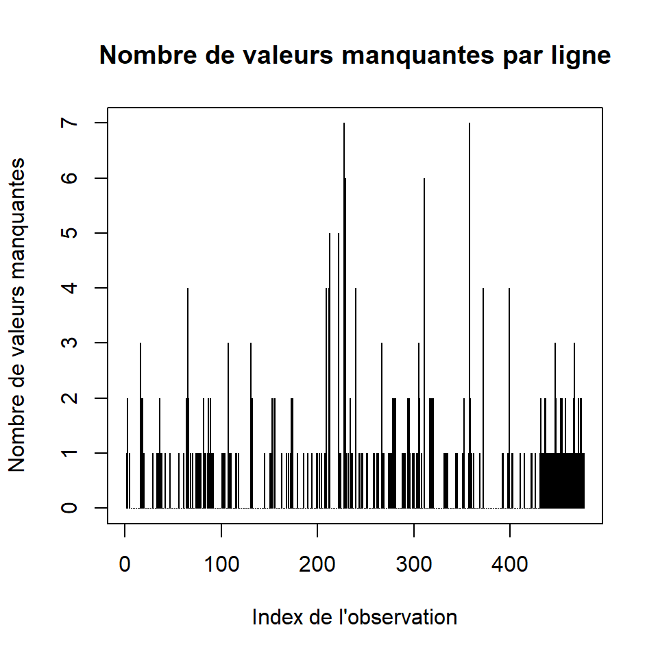

```r
num_missing <- rowSums(is.na(cylinder3))
plot(num_missing, type='h', main='Nombre de valeurs manquantes par ligne', xlab='Index de l\'observation', ylab='Nombre de valeurs manquantes')
```

## 3.4 Traitement des données aberrantes

Premièrement, visualisons les boites à moustaches des variables numériques pour détecter les valeurs aberrantes dans chaque colonne.

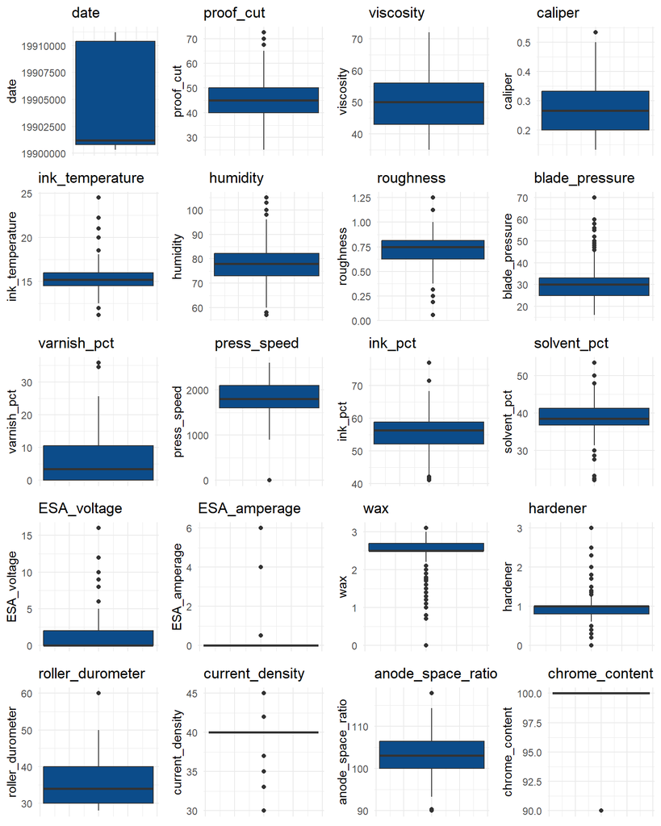

```r
numeric_cols <- names(cylinder3)[sapply(cylinder3, is.numeric)]

plots <- list()

for (i in seq_along(numeric_cols)) {
  plots[[i]] <- ggplot(cylinder3, aes_string(y = numeric_cols[i])) +
    geom_boxplot(fill = "#0c4c8a") +
    labs(title = numeric_cols[i]) +
    theme_minimal() +
    theme(axis.text.x = element_blank(), axis.ticks.x = element_blank())
}

do.call(grid.arrange, c(plots, ncol = 4))
```

On remarque sur le graphique précédent que la plupart des attributs ont des valeurs aberrantes. Il est difficile de dire si certaines de ces valeurs sont de vraies valeurs aberrantes car il faudrait une connaissance accrue dans l’impression rotogravure. Cependant, certaines valeurs aberrantes paraissent plus suspectes que d’autres. Les voici :

- la valeur de la press_speed à 0.
- les valeurs “ESA_amperage” supérieurs à 2
- les valeurs où l’humidité est supérieure à 100. Cependant, d’après quelques recherches, des tels taux d’humidité serait possibles mais très étrange dans ce domaine.

Puisque ces valeurs semblent très suspectes et peu nombreuses, nous allons supprimer la ligne complète dans lesquelles elles apparaissent.

```r
cylinder4 <- filter(cylinder3, press_speed != 0 | is.na(press_speed),
                    humidity <= 100 | is.na(humidity),
                    ESA_amperage < 2 | is.na(ESA_amperage))
```

## 3.5 Traitement des données manquantes

Pour les variables numériques, nous remplaçons les valeurs manquantes en utilisant Knn. Il s’agit d’un algorithme de machine learning qui cherche les plus proches voisins (10 dans notre cas) pour remplacer les valeurs manquantes.

```r
numeric_cols <- sapply(cylinder4, is.numeric)
numeric_cylinder <- cylinder4[, numeric_cols]
numeric_cylinder_imputed <- knnImputation(numeric_cylinder)
cylinder4[, numeric_cols] <- numeric_cylinder_imputed
```

Pour les variables catégorielles, nous ajoutons une nouvelle catégorie “manquante” et ajoutons les valeurs manquantes dans celle-ci.

```r
categorical_cols <- names(cylinder4)[sapply(cylinder4, is.factor)]
cylinder4 <- cylinder4 %>%
  mutate(across(all_of(categorical_cols), ~replace_na(as.character(.), "manquante"))) %>%
  mutate(across(all_of(categorical_cols), factor))
```

```r
summary(cylinder4)
```

```
      date            proof_cut       viscosity        caliper
 Min.   :19900330   Min.   :25.00   Min.   :35.00   Min.   :0.1330
 1st Qu.:19900820   1st Qu.:40.00   1st Qu.:43.00   1st Qu.:0.2000
 Median :19901214   Median :45.00   Median :50.00   Median :0.2670
 Mean   :19905421   Mean   :44.97   Mean   :51.02   Mean   :0.2766
 3rd Qu.:19910409   3rd Qu.:50.00   3rd Qu.:56.00   3rd Qu.:0.3183
 Max.   :19911211   Max.   :72.50   Max.   :72.00   Max.   :0.5330

 ink_temperature    humidity       roughness       blade_pressure
 Min.   :11.20   Min.   : 57.0   Min.   :0.05625   Min.   :16.00
 1st Qu.:14.50   1st Qu.: 73.0   1st Qu.:0.62500   1st Qu.:25.00
 Median :15.20   Median : 78.0   Median :0.75000   Median :30.00
 Mean   :15.32   Mean   : 78.4   Mean   :0.73024   Mean   :31.08
 3rd Qu.:16.00   3rd Qu.: 82.0   3rd Qu.:0.81250   3rd Qu.:33.91
 Max.   :24.50   Max.   :100.0   Max.   :1.25000   Max.   :60.00

  varnish_pct      press_speed      ink_pct       solvent_pct
 Min.   : 0.000   Min.   : 900   Min.   :41.00   Min.   :22.00
 1st Qu.: 0.000   1st Qu.:1600   1st Qu.:52.12   1st Qu.:36.73
 Median : 3.400   Median :1800   Median :56.80   Median :38.50
 Mean   : 5.785   Mean   :1840   Mean   :55.69   Mean   :38.51
 3rd Qu.:10.475   3rd Qu.:2100   3rd Qu.:58.80   3rd Qu.:41.20
 Max.   :35.800   Max.   :2600   Max.   :76.90   Max.   :53.40

  ESA_voltage      ESA_amperage           wax           hardener
 Min.   : 0.000   Min.   :0.000000   Min.   :0.000   Min.   :0.0000
 1st Qu.: 0.000   1st Qu.:0.000000   1st Qu.:2.423   1st Qu.:0.8000
 Median : 0.000   Median :0.000000   Median :2.500   Median :1.0000
 Mean   : 1.352   Mean   :0.001064   Mean   :2.425   Mean   :0.9665
 3rd Qu.: 2.000   3rd Qu.:0.000000   3rd Qu.:2.700   3rd Qu.:1.0000
 Max.   :16.000   Max.   :0.500000   Max.   :3.100   Max.   :3.0000

 roller_durometer current_density anode_space_ratio chrome_content
 Min.   :28.00    Min.   :30.00   Min.   : 90.0     Min.   : 90.00
 1st Qu.:30.00    1st Qu.:40.00   1st Qu.:100.0     1st Qu.:100.00
 Median :34.00    Median :40.00   Median :103.1     Median :100.00
 Mean   :34.66    Mean   :38.96   Mean   :103.0     Mean   : 99.66
 3rd Qu.:40.00    3rd Qu.:40.00   3rd Qu.:106.5     3rd Qu.:100.00
 Max.   :60.00    Max.   :45.00   Max.   :117.9     Max.   :100.00

```

[output cut: 20 more lines]

```
                                                          woodhoe70:161



     press    unit_number cylinder_size         location      plating_tank
 816    :82   1 : 31      catalog:154   canadian    :158   1910     :294
 815    :79   10:  7      spiegel: 50   manquante   : 93   1911     :159
 821    :63   2 :210      tabloid:266   mideuropean : 15   manquante: 17
 802    :58   5 : 10                    northus     :183
 824    :55   6 :  4                    scandanavian: 13
 827    :54   7 : 71                    southus     :  8
 (Other):79   9 :137
  band_type
 band  :162
 noband:308
```

## 3.6 Suppression des attributs non pertinents

Dans cette étape, nous allons analyser les attributs non pertinents pour la détection de bandes qui seront supprimés par la suite.

### 3.6.1 Attributs catégoriels

Premièrement, le numéro de cylindre est un identifiant unique du cylindre et comme mentionné dans la documentation du jeu de données, on ne doit pas le sélectionner pour la sélection d’attributs.

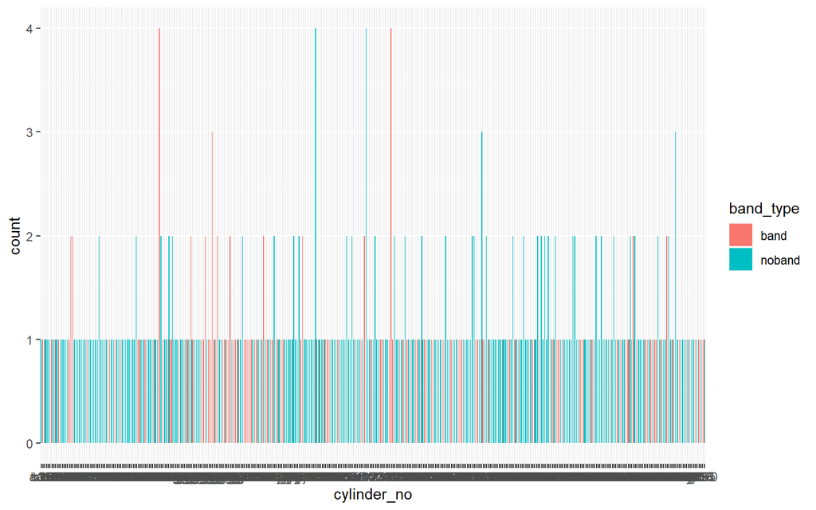

```r
ggplot(cylinder4, aes(x = cylinder_no, fill = band_type)) + geom_bar(position = position_dodge(preserve = "single"))
```

Le numéro de client est lui aussi inutile dans notre cas. Il aurait été intéressant de savoir ce qu’ils impriment pour pouvoir ensuite déterminer à l’aide du graphique ci-dessous les impressions à privilégier ou à éviter.

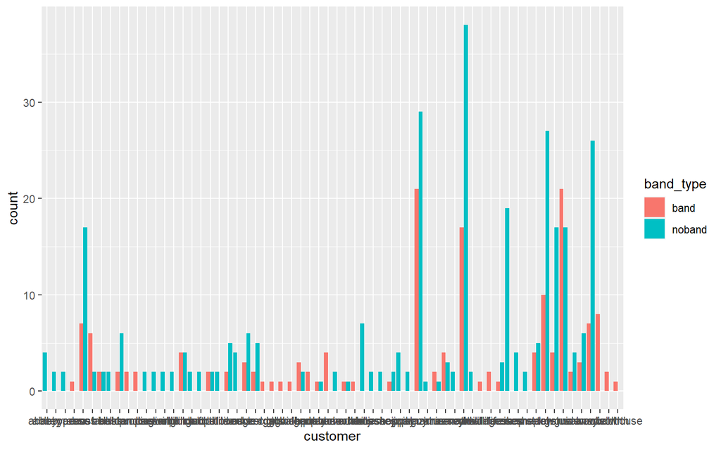

```r
ggplot(cylinder4, aes(x = customer, fill = band_type)) + geom_bar(position = position_dodge(preserve = "single"))
```

Nous n’allons pas utiliser job_number pour les mêmes raisons que le numéro de clients. A nouveau, il aurait été intéressant de savoir à quelles images d’impressions sont liées les jobs d’impressions.

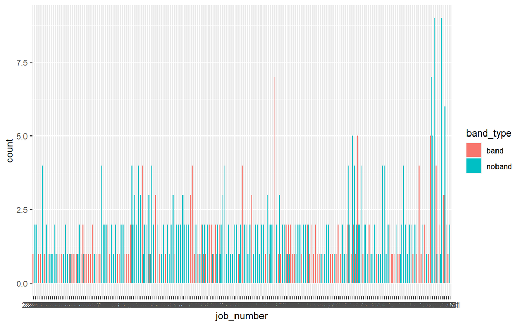

```r
ggplot(cylinder4, aes(x = job_number, fill = band_type)) + geom_bar(position = position_dodge(preserve = "single"))
```

Ink_color n’est pas très utile non plus puisqu’elle ne contient qu’une valeur distincte. Cela ne nous permettra pas de déterminer si cette variable cause des problèmes d’impression ou non. Cependant, s’il y avait eu des valeurs manquantes, nous aurions pu voir si ces valeurs suivaient une certaine tendance ou non.

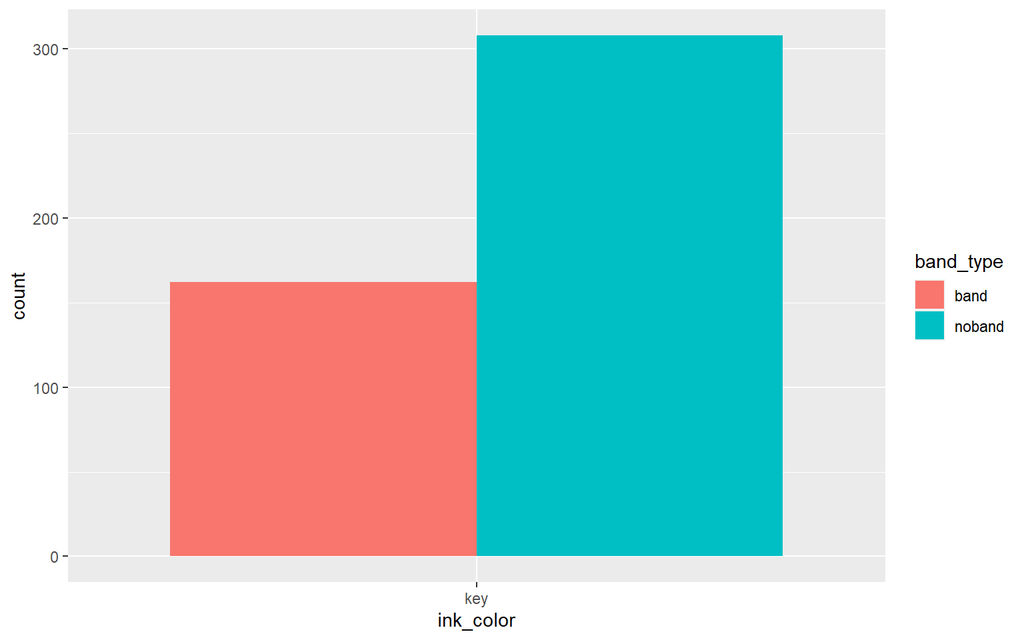

```r
ggplot(cylinder4, aes(x = ink_color, fill = band_type)) + geom_bar(position = position_dodge(preserve = "single"))
```

La variable proof_ink n’est pas non plus très pertinente dû à son faible nombre d’observation “no”. Il est donc difficile de tenter de généraliser quelque chose.

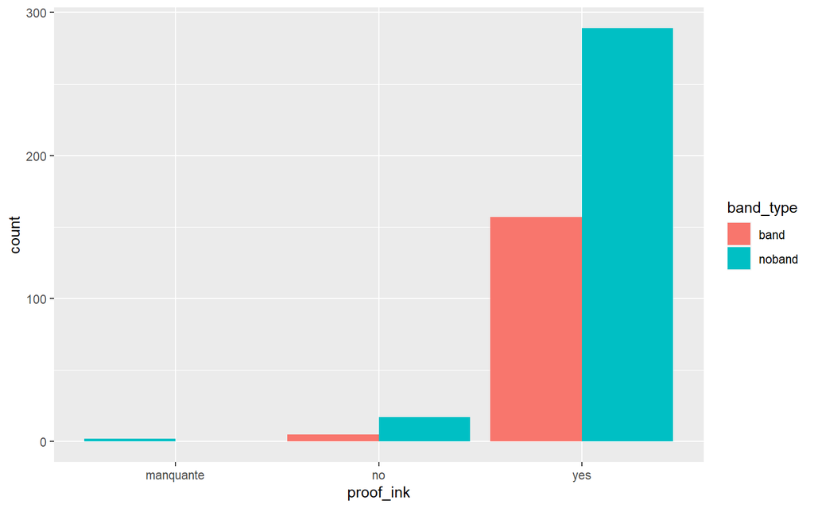

```r
ggplot(cylinder4, aes(x = proof_ink, fill = band_type)) + geom_bar(position = position_dodge(preserve = "single"))
```

La variable blade_mfg n’est pas non plus très pertinente dû à son faible nombre d’observation “uddeholm”. A nouveau, il est difficile de tenter de généraliser quelque chose.

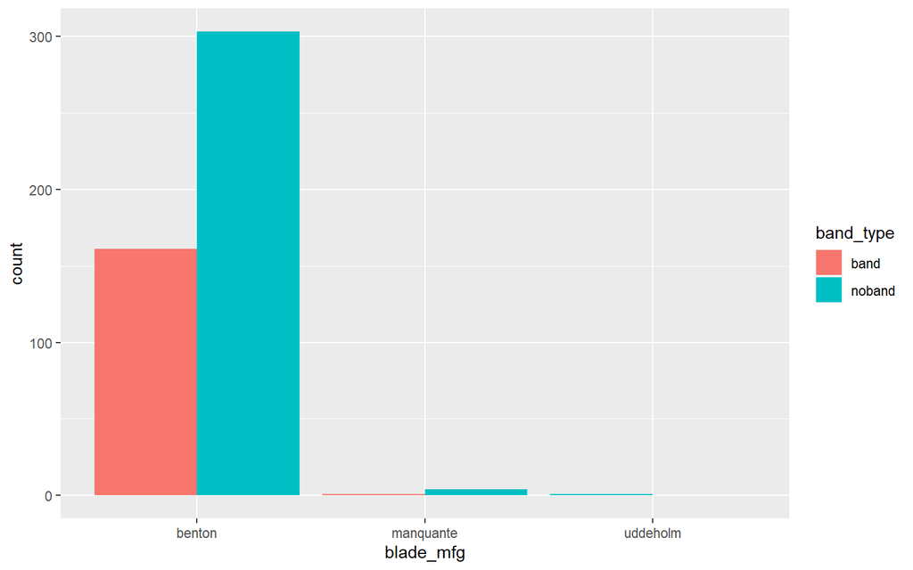

```r
ggplot(cylinder4, aes(x = blade_mfg, fill = band_type)) + geom_bar(position = position_dodge(preserve = "single"))
```

A nouveau, cylinder_division ne comporte qu’une seule division et n’est donc pas utile.

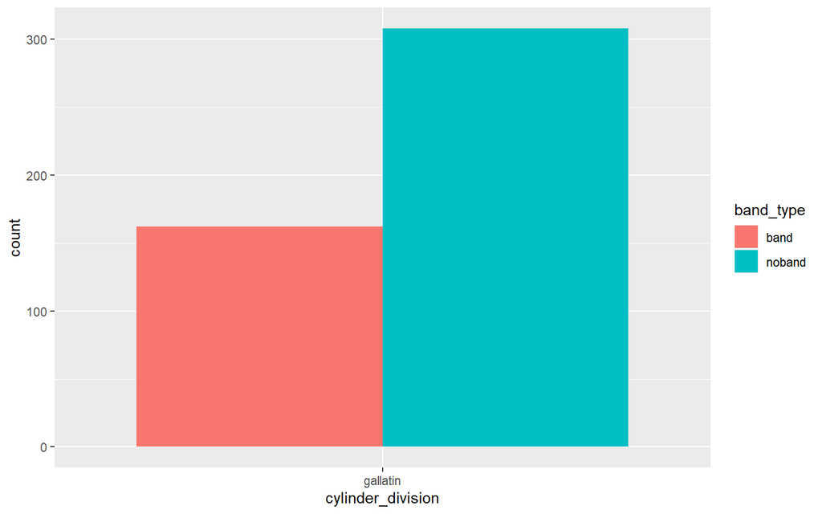

```r
ggplot(cylinder4, aes(x = cylinder_division, fill = band_type)) + geom_bar(position = position_dodge(preserve = "single"))
```

Pour la variable direct_steam, nous avons uniquement une seul valeur composant la 2ème catégorie. Cette variable ne permet donc pas de détecter certaines tendances.

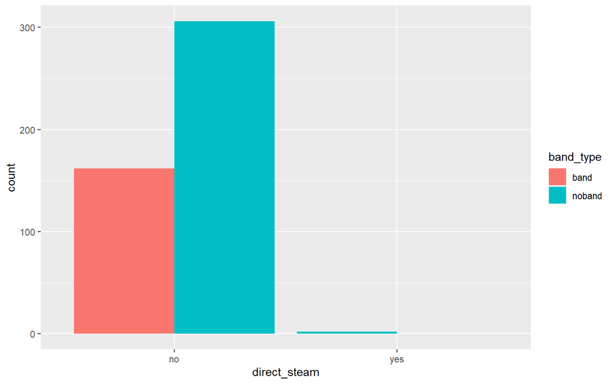

```r
ggplot(cylinder4, aes(x = direct_steam, fill = band_type)) + geom_bar(position = position_dodge(preserve = "single"))
```

### 3.6.2 Attributs numériques

Pour les attributs numériques, il est important de visualiser la corrélation entre chacune des variables. Dans ce cas, on remarque une forte corrélation entre ink_pct et varnish_pct et entre varnish_pct et solvent_pct.

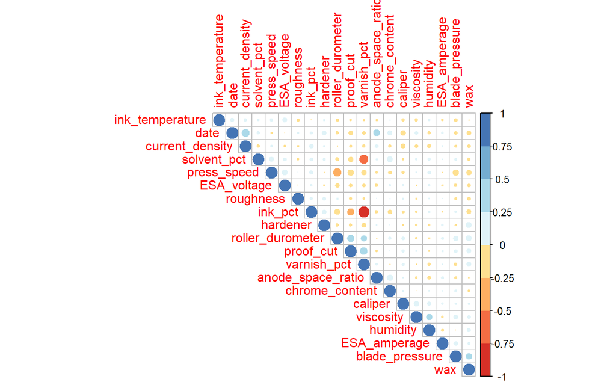

```r
numeric_cols <- select_if(cylinder4, is.numeric)
corr <- cor(numeric_cols)

corrplot(corr, type="upper", order="hclust",
         col=brewer.pal(n=8, name="RdYlBu"))
```

Nous pouvons voir la corrélation entre ink_pct et varnish_pct sur ce graphique.

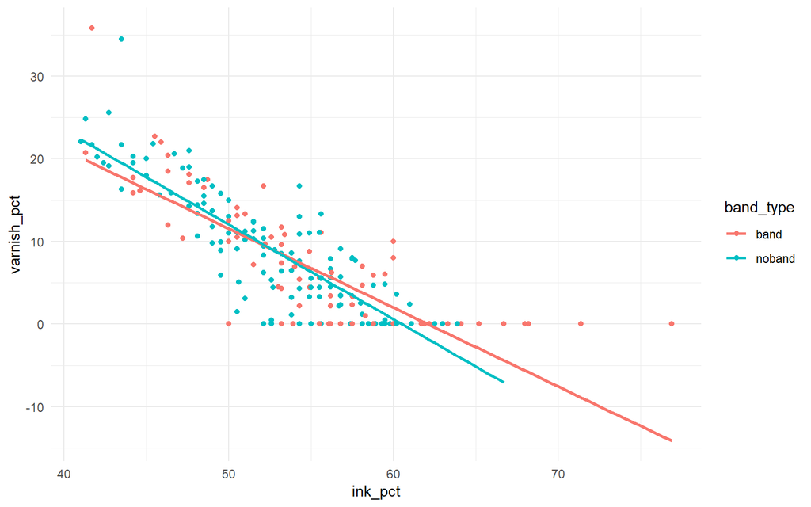

```r
ggplot(cylinder4, aes(x = ink_pct, y = varnish_pct, color = band_type)) +
  geom_point() +
  labs(x = "ink_pct", y = "varnish_pct") +
  theme_minimal() +
  geom_smooth(method = "lm", se = FALSE)
```

Nous pouvons voir la corrélation entre solvent_pct et varnish_pct sur ce graphique.

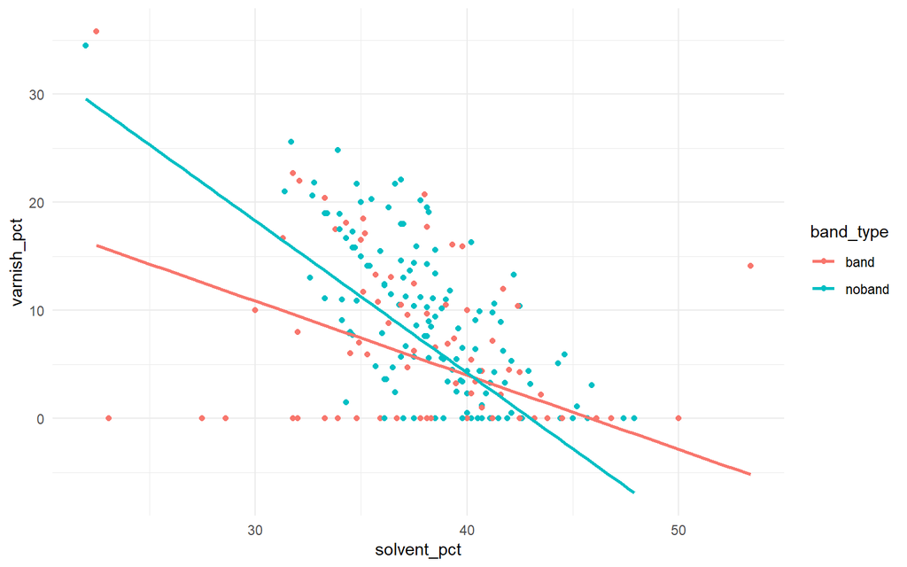

```r
ggplot(cylinder4, aes(x = solvent_pct, y = varnish_pct, color = band_type)) +
  geom_point() +
  labs(x = "solvent_pct", y = "varnish_pct") +
  theme_minimal() +
  geom_smooth(method = "lm", se = FALSE)
```

Maintenant, nous allons observer les variables numériques n’étant pas très utile pour la détection de bandes. Pour cela, nous allons utilisé les diagrammes en violons. Si les 2 violons ont exactement la même forme, cela permet de déterminer que la variable n’est pas très pertinente.

Dans ce premier cas, on remarque que les 2 violons sont très similaires suite à la suppression des valeurs bruitées qui se trouvaient à la fin du jeu de données. On en déduit que la date n’est pas très pertinente.

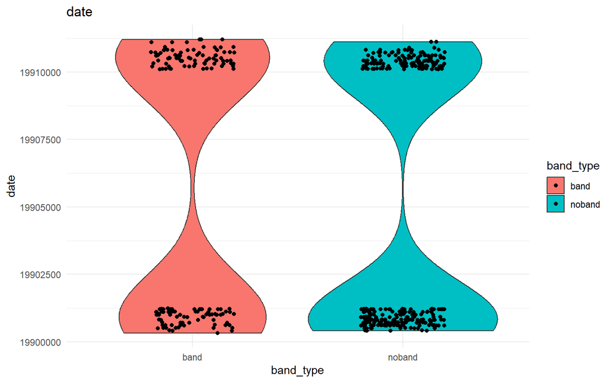

```r
ggplot(cylinder4, aes_string(x="band_type", y="date", fill="band_type")) +
       geom_violin() +
       geom_jitter(aes(color=band_type), width=0.2, height = 0.1, color="black") +
       labs(title="date", y="date") +
  theme_minimal()
```

A nouveau, les 2 violons sont presque identiques. On en déduit que varnish_pct n’est pas très pertinent. De plus, la suppression de varnish_pct nous permet d’éviter le problème de multi-colinéarité dans la recherche des meilleurs attributs puisque celle-ci était corrélée avec ink_pct et solvent_pct.

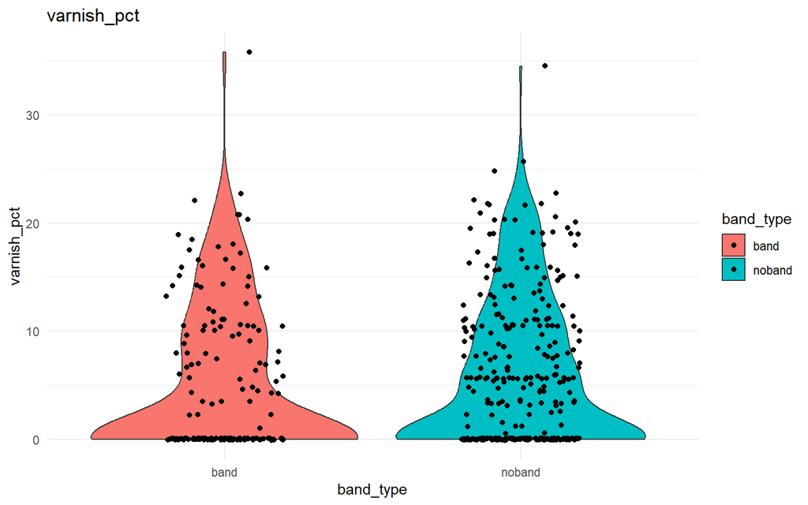

```r
ggplot(cylinder4, aes_string(x="band_type", y="varnish_pct", fill="band_type")) +
       geom_violin() +
       geom_jitter(aes(color=band_type), width=0.2, height = 0.1, color="black") +
       labs(title="varnish_pct", y="varnish_pct") +
  theme_minimal()
```

Cela fait, nous pouvons supprimer toutes les variables non pertinentes de notre jeu de données.

```r
cylinder4 <- subset(cylinder4, select = -c(cylinder_no, customer, job_number, ink_color, cylinder_division, direct_steam, proof_ink, blade_mfg, date, varnish_pct))
```

Voici, à nouveau un résumé du jeu de données après la suppression des variables non pertinentes.

```r
summary(cylinder4)
```

```
   proof_cut       viscosity        caliper       ink_temperature
 Min.   :25.00   Min.   :35.00   Min.   :0.1330   Min.   :11.20
 1st Qu.:40.00   1st Qu.:43.00   1st Qu.:0.2000   1st Qu.:14.50
 Median :45.00   Median :50.00   Median :0.2670   Median :15.20
 Mean   :44.97   Mean   :51.02   Mean   :0.2766   Mean   :15.32
 3rd Qu.:50.00   3rd Qu.:56.00   3rd Qu.:0.3183   3rd Qu.:16.00
 Max.   :72.50   Max.   :72.00   Max.   :0.5330   Max.   :24.50

    humidity       roughness       blade_pressure   press_speed
 Min.   : 57.0   Min.   :0.05625   Min.   :16.00   Min.   : 900
 1st Qu.: 73.0   1st Qu.:0.62500   1st Qu.:25.00   1st Qu.:1600
 Median : 78.0   Median :0.75000   Median :30.00   Median :1800
 Mean   : 78.4   Mean   :0.73024   Mean   :31.08   Mean   :1840
 3rd Qu.: 82.0   3rd Qu.:0.81250   3rd Qu.:33.91   3rd Qu.:2100
 Max.   :100.0   Max.   :1.25000   Max.   :60.00   Max.   :2600

    ink_pct       solvent_pct     ESA_voltage      ESA_amperage
 Min.   :41.00   Min.   :22.00   Min.   : 0.000   Min.   :0.000000
 1st Qu.:52.12   1st Qu.:36.73   1st Qu.: 0.000   1st Qu.:0.000000
 Median :56.80   Median :38.50   Median : 0.000   Median :0.000000
 Mean   :55.69   Mean   :38.51   Mean   : 1.352   Mean   :0.001064
 3rd Qu.:58.80   3rd Qu.:41.20   3rd Qu.: 2.000   3rd Qu.:0.000000
 Max.   :76.90   Max.   :53.40   Max.   :16.000   Max.   :0.500000

      wax           hardener      roller_durometer current_density
 Min.   :0.000   Min.   :0.0000   Min.   :28.00    Min.   :30.00
 1st Qu.:2.423   1st Qu.:0.8000   1st Qu.:30.00    1st Qu.:40.00
 Median :2.500   Median :1.0000   Median :34.00    Median :40.00
 Mean   :2.425   Mean   :0.9665   Mean   :34.66    Mean   :38.96
 3rd Qu.:2.700   3rd Qu.:1.0000   3rd Qu.:40.00    3rd Qu.:40.00
 Max.   :3.100   Max.   :3.0000   Max.   :60.00    Max.   :45.00

 anode_space_ratio chrome_content     grain_screened    paper_type
 Min.   : 90.0     Min.   : 90.00   manquante: 10    coated  :206
 1st Qu.:100.0     1st Qu.:100.00   no       :265    uncoated:264
 Median :103.1     Median :100.00   yes      :195
 Mean   :103.0     Mean   : 99.66
 3rd Qu.:106.5     3rd Qu.:100.00
 Max.   :117.9     Max.   :100.00

     ink_type   solvent_type   cylinder_type     press_type      press
 coated  :261   line  :454   manquante:  8   albert70 : 58   816    :82
 cover   : 13   naptha:  2   no       :128   motter70 : 45   815    :79
 uncoated:196   xylol : 14   yes      :334   motter94 :206   821    :63
                                             woodhoe70:161   802    :58
                                                             824    :55
                                                             827    :54
                                                             (Other):79
 unit_number cylinder_size         location      plating_tank  band_type
 1 : 31      catalog:154   canadian    :158   1910     :294   band  :162
 10:  7      spiegel: 50   manquante   : 93   1911     :159   noband:308
 2 :210      tabloid:266   mideuropean : 15   manquante: 17
 5 : 10                    northus     :183
 6 :  4                    scandanavian: 13
 7 : 71                    southus     :  8
 9 :137
```

# 4 Sélection des attributs

Dans cette étape, nous allons sélectionner les attributs les plus importants pour tenter de réduire ou éliminer les défauts de bandes. Pour cela, nous allons utiliser plusieurs méthodes pour tenter d’extraire un maximum d’informations. Cela comprend la visualisation des attributs à l’aide de graphique, la création d’arbres de classification et l’utilisation des randomForest.

## 4.1 Visualisations des attributs

Premièrement, nous allons tenter de déterminer quels attributs pourraient avoir un impact sur les défauts d’impression à l’aide de graphiques.

Voici probablement l’une des variables les plus importantes. Ce graphique nous permet de constater que 3 presses spécifiques sont bien moins performantes que les autres. Il s’agit des presses 815, 816 et 821. La presse 815 a même un taux de plus de 50% de bandes. Il faudrait donc privilégier les presses 802, 813, 824, 827 et 828.

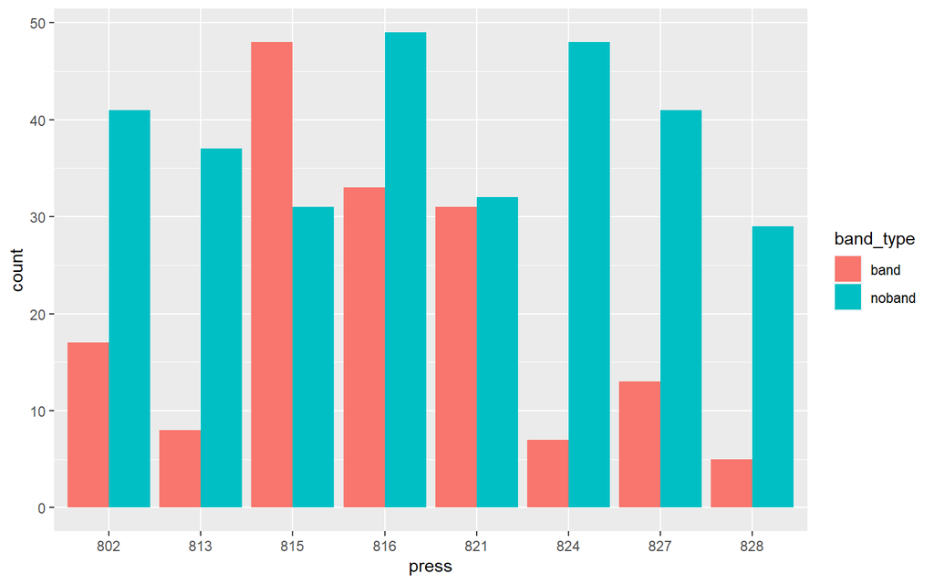

```r
ggplot(cylinder4, aes(x = press, fill = band_type)) + geom_bar(position = position_dodge(preserve = "single"))
```

Ce 2ème graphique nous permet de constater que les types de presse jouent aussi un rôle important. En effet, le type woodhoe70 est celui qui produit le plus de bandes. Il faudrait privilégier les types motter70, moter94 puis albert70.

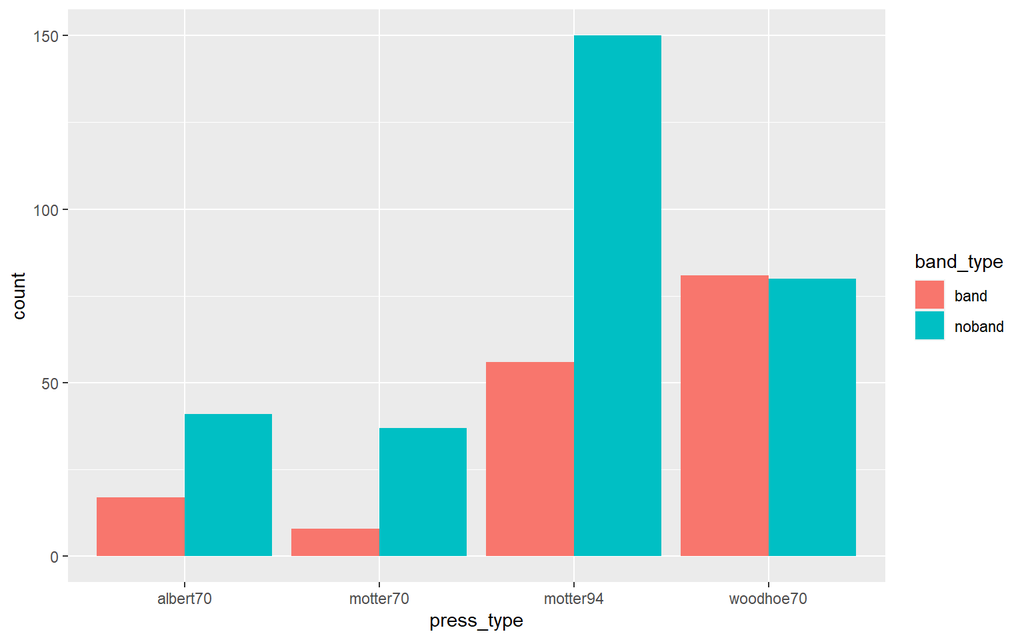

```r
ggplot(cylinder4, aes(x = press_type, fill = band_type)) + geom_bar(position = position_dodge(preserve = "single"))
```

Dans ce graphique, on remarque qu’il est préférable de privilégier une texture non tamisée.

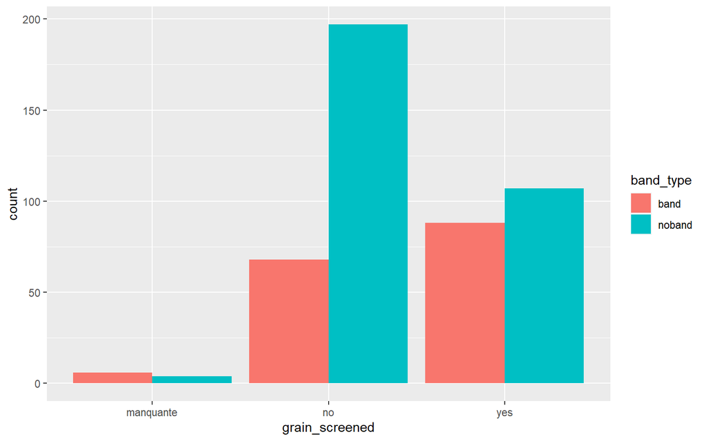

```r
ggplot(cylinder4, aes(x = grain_screened, fill = band_type)) + geom_bar(position = position_dodge(preserve = "single"))
```

Le type de l’encre joue aussi un rôle important. On remarque que la catégorie coated est bien meilleur que les 2 autres. Le type cover est lui à éviter.

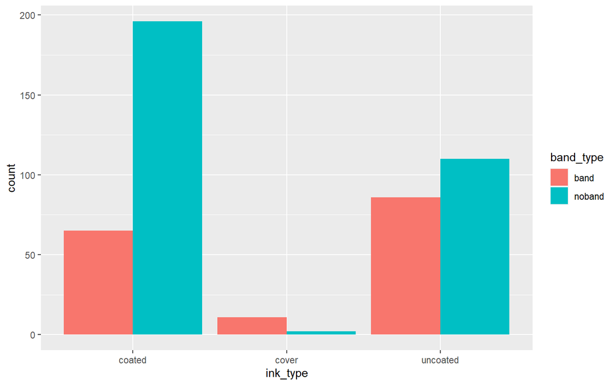

```r
ggplot(cylinder4, aes(x = ink_type, fill = band_type)) + geom_bar(position = position_dodge(preserve = "single"))
```

Le type de papier est aussi un argument à prendre en compte. Il y a plus de probabilité d’avoir des bandes en utilisant le type de papier uncoated par rapport à coated.

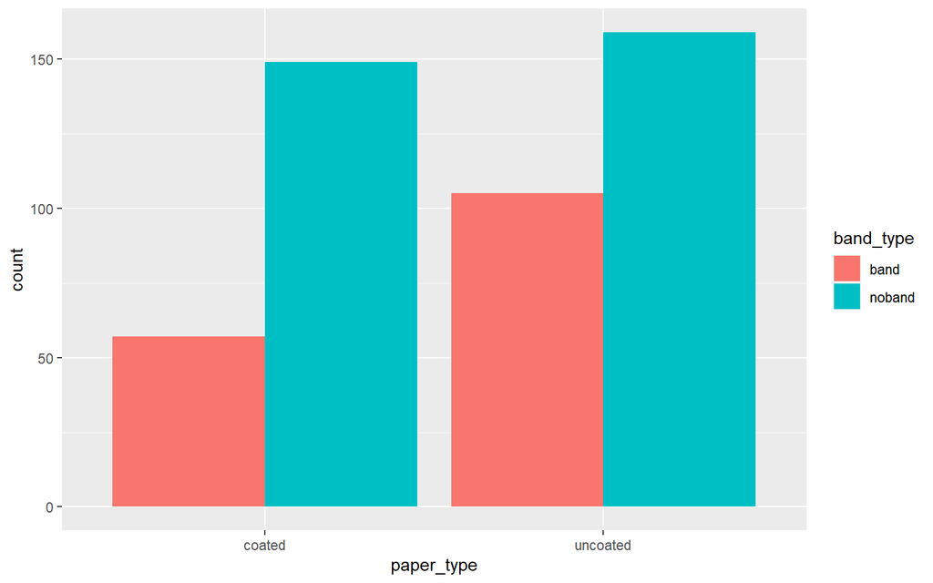

```r
ggplot(cylinder4, aes(x = paper_type, fill = band_type)) + geom_bar(position = position_dodge(preserve = "single"))
```

Ce graphique démontre que les cylindres qui ont des types ont beaucoup moins de chance de produire des bandes que les cylindres qui n’ont pas de types.

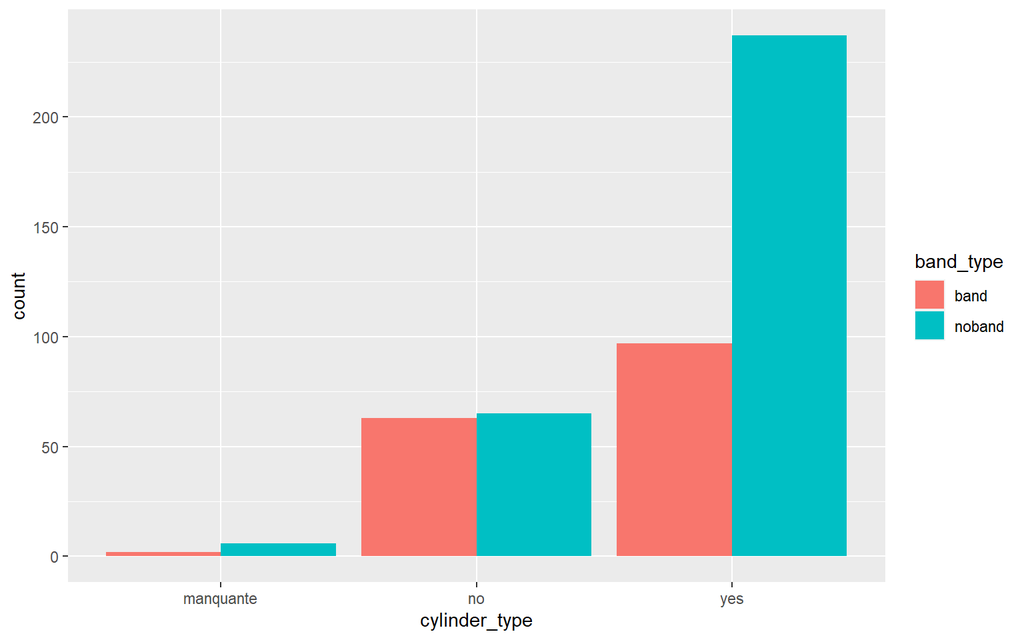

```r
ggplot(cylinder4, aes(x = cylinder_type, fill = band_type)) + geom_bar(position = position_dodge(preserve = "single"))
```

La taille du cylindre est aussi un paramètre à prendre en compte. Bien que les 3 catégories offrent moins de 50% de bandes, il semblerait que les tailles de cylindres “catalog” et “tabloid” soient meilleurs que “spiegel”.

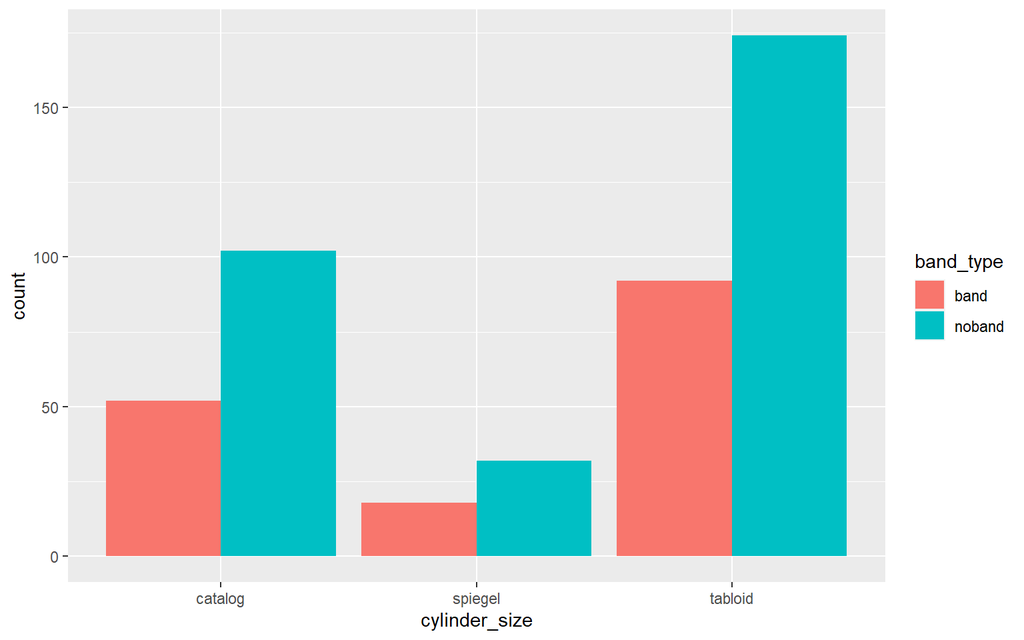

```r
ggplot(cylinder4, aes(x = cylinder_size, fill = band_type)) + geom_bar(position = position_dodge(preserve = "single"))
```

La localisation du fabriquant de papier permet visiblement aussi de départager certaines d’entre-elles. En effet il y a moins de chance d’obtenir des bandes lorsque le fabriquant de papier utilisé est au Canada ou en Amérique du Nord.

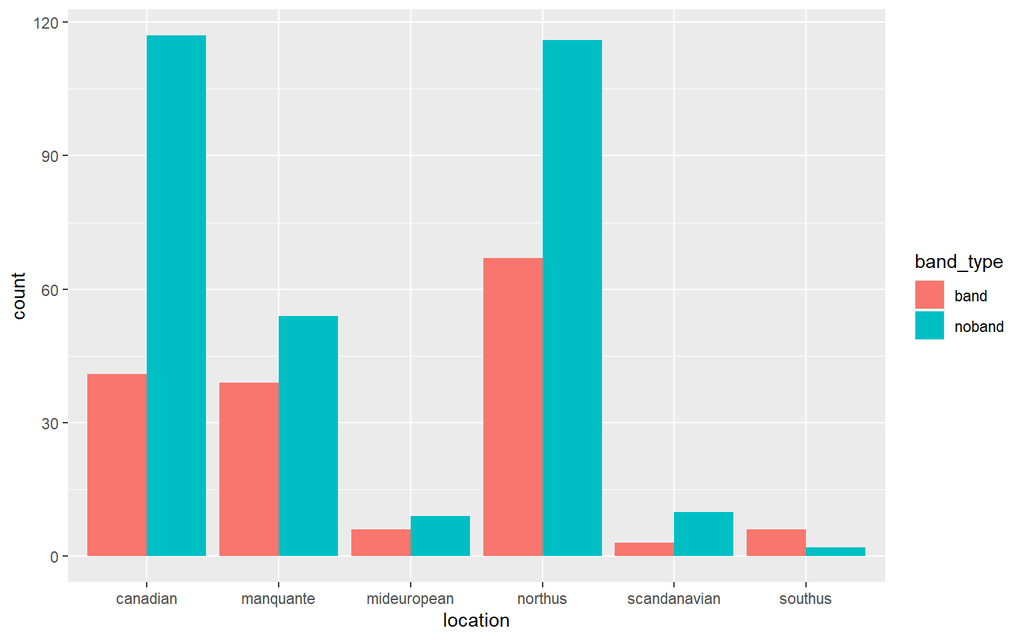

```r
ggplot(cylinder4, aes(x = location, fill = band_type)) + geom_bar(position = position_dodge(preserve = "single"))
```

Pour les variables numériques, une des variables qui est probablement la plus importante pour éviter les bandes est la vitesse de la presse. En effet, la vitesse de la presse à l’air de jouer un gros rôle sur la production de bandes. Il semblerait qu’une vitesse inférieure à 1250 produit que des bandes alors que le cas inverse se produit lorsque la vitesse de la bande est environ supérieure à 2400.

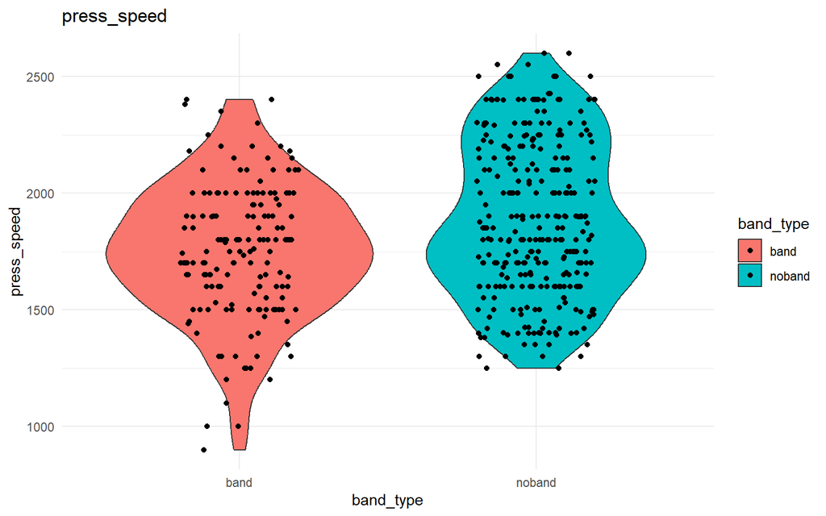

```r
ggplot(cylinder4, aes_string(x="band_type", y="press_speed", fill="band_type")) +
       geom_violin() +
       geom_jitter(aes(color=band_type), width=0.2, height = 0.1, color="black") +
       labs(title="press_speed", y="press_speed") +
  theme_minimal()
```

Pour la température de l’encre, on remarque que les 2 graphiques ont des formes assez différentes. Il semblerait qu’une température supérieure à 20° produirait uniquement des bandes. La température à privilégier serait environ 16° car on remarque une forte différence de largeur des violons à cette valeur-là.

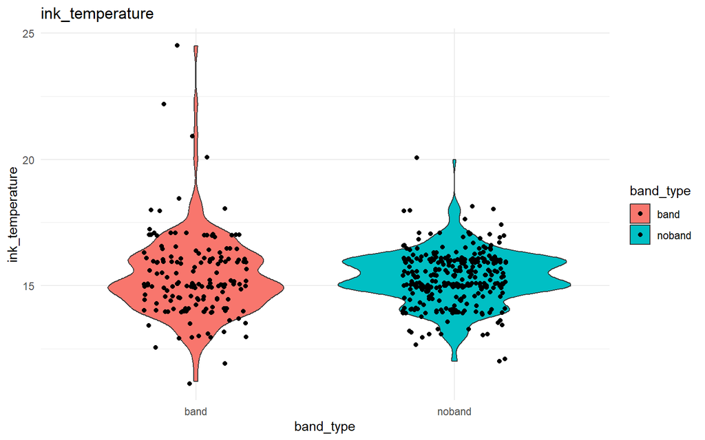

```r
ggplot(cylinder4, aes_string(x="band_type", y="ink_temperature", fill="band_type")) +
       geom_violin() +
       geom_jitter(aes(color=band_type), width=0.2, height = 0.1, color="black") +
       labs(title="ink_temperature", y="ink_temperature") +
  theme_minimal()
```

Pour le pourcentage d’encre, la forme des violons est assez similaire. Cependant, uniquement des bandes serait produites à partir d’environ 66%.

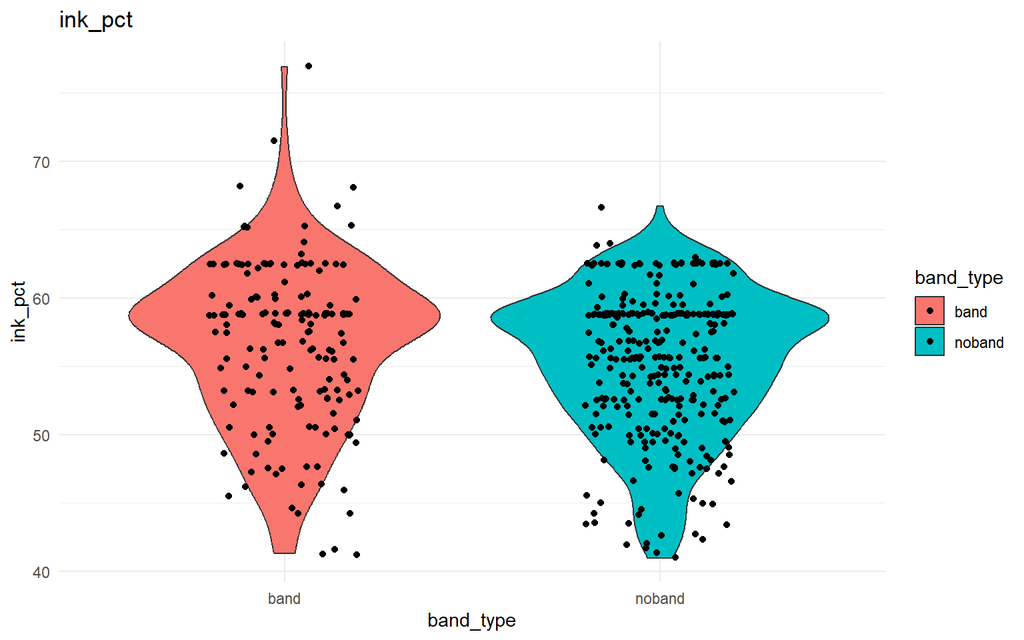

```r
ggplot(cylinder4, aes_string(x="band_type", y="ink_pct", fill="band_type")) +
       geom_violin() +
       geom_jitter(aes(color=band_type), width=0.2, height = 0.1, color="black") +
       labs(title="ink_pct", y="ink_pct") +
  theme_minimal()
```

La forme des 2 violons sont assez différentes pour la viscosité. Premièrement, on distingue aucune bande en dessous d’environ 38. De plus, la viscosité à privilégier serait d’environ 55 puisque la différence entre la largeur des 2 violons et la plus grande.

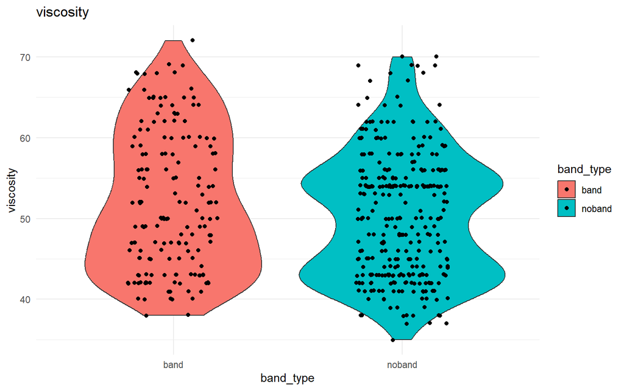

```r
ggplot(cylinder4, aes_string(x="band_type", y="viscosity", fill="band_type")) +
       geom_violin() +
       geom_jitter(aes(color=band_type), width=0.2, height = 0.1, color="black") +
       labs(title="viscosity", y="viscosity") +
  theme_minimal()
```

Pour l’humidité, les violons sont assez similaires. On pourrait dire qu’il est préférable d’avoir un taux d’humidité d’environ 70% mais il est difficile de déterminer uniquement à l’aide de ce paramètre si les impressions auront des bandes.

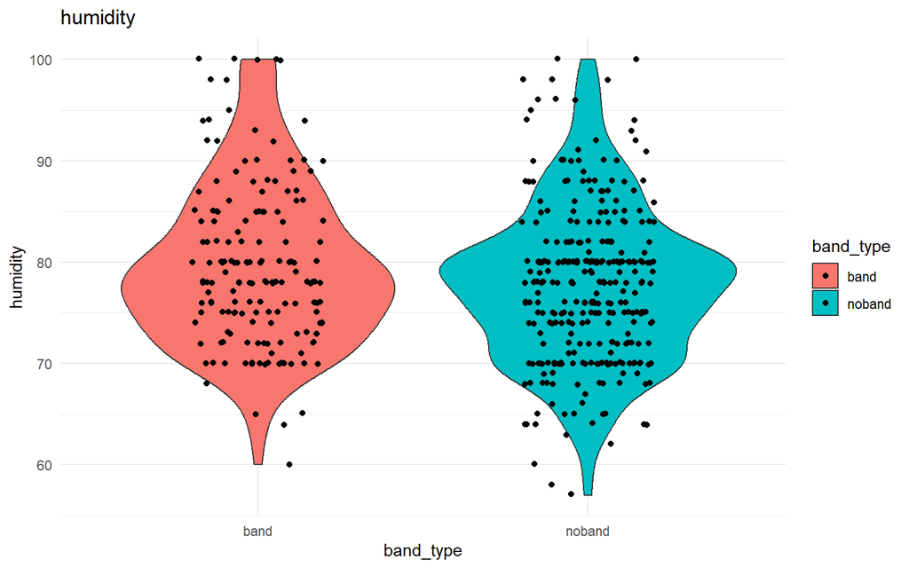

```r
ggplot(cylinder4, aes_string(x="band_type", y="humidity", fill="band_type")) +
       geom_violin() +
       geom_jitter(aes(color=band_type), width=0.2, height = 0.1, color="black") +
       labs(title="humidity", y="humidity") +
  theme_minimal()
```

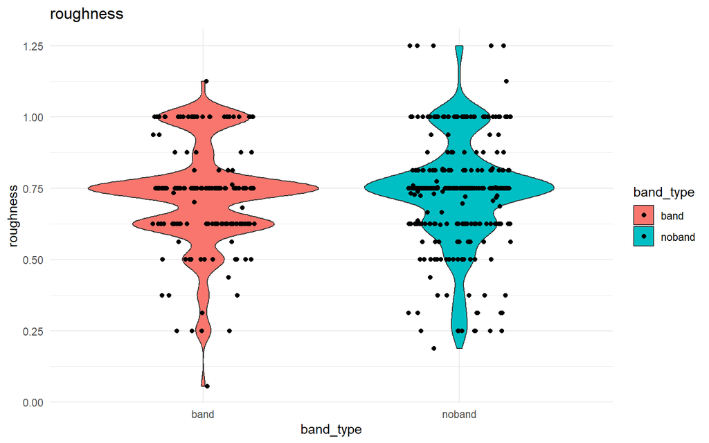

```r
ggplot(cylinder4, aes_string(x="band_type", y="roughness", fill="band_type")) +
       geom_violin() +
       geom_jitter(aes(color=band_type), width=0.2, height = 0.0, color="black") +
       labs(title="roughness", y="roughness") +
  theme_minimal()
```

Pour la pression de la lame, on peut dire qu’une valeur inférieure à 20 produits uniquement des bandes. Pour le reste, la forme des violons est assez similaires.

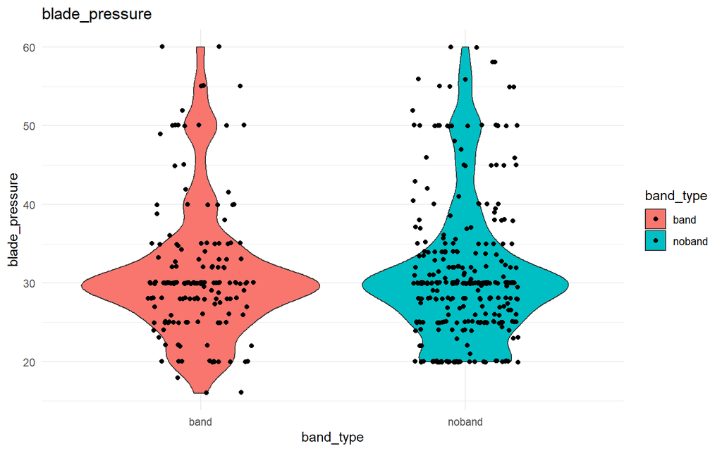

```r
ggplot(cylinder4, aes_string(x="band_type", y="blade_pressure", fill="band_type")) +
       geom_violin() +
       geom_jitter(aes(color=band_type), width=0.2, height = 0.1, color="black") +
       labs(title="blade_pressure", y="blade_pressure") +
  theme_minimal()
```